# SUMMARY SESSION 6

```r
###

Beer.ima <- arima(Beer.ts, order = c(0, 1, 1))
Beer.ima
```

```
Call:
arima(x = Beer.ts, order = c(0, 1, 1))

Coefficients:
          ma1
      -0.3334
s.e.   0.0558

sigma^2 estimated as 360.4:  log likelihood = -1723.27,  aic = 3448.53
```

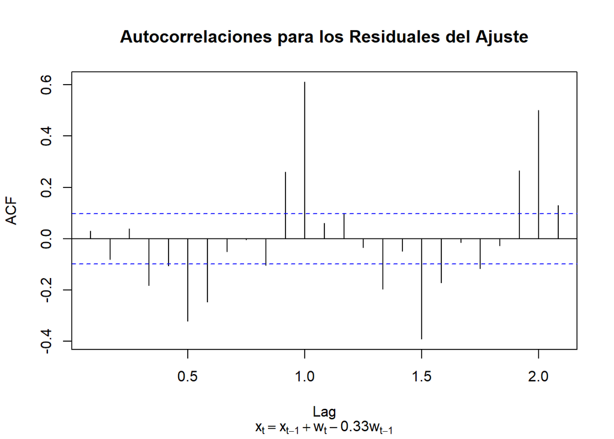

```r
###

acf(resid(Beer.ima), main = "")
title(main = "Autocorrelaciones para los Residuales del Ajuste",
      sub = expression(x[t]==x[t-1]+w[t]-0.33*w[t-1]))
```

```r
###

Beer.1991 <- predict(Beer.ima, n.ahead = 12)
sum(Beer.1991$pred)
```

```
[1] 2365.412
```

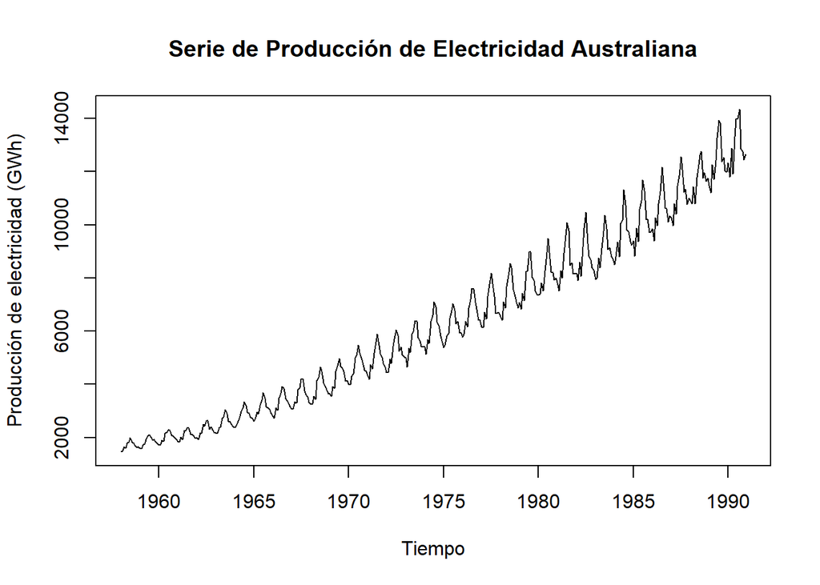

```r
#### Modelos Arima estacionales

# Procedimiento de ajuste
# Serie de Producción de Electricidad de Australia

CBE <- read.csv("cbe.csv", header = TRUE)
Elec.ts <- ts(CBE[, 3], start = 1958, freq = 12)
plot(Elec.ts, xlab = "", ylab = "")
title(main = "Serie de Producción de Electricidad Australiana",
      ylab = "Producción de electricidad (GWh)",
      xlab = "Tiempo")
```

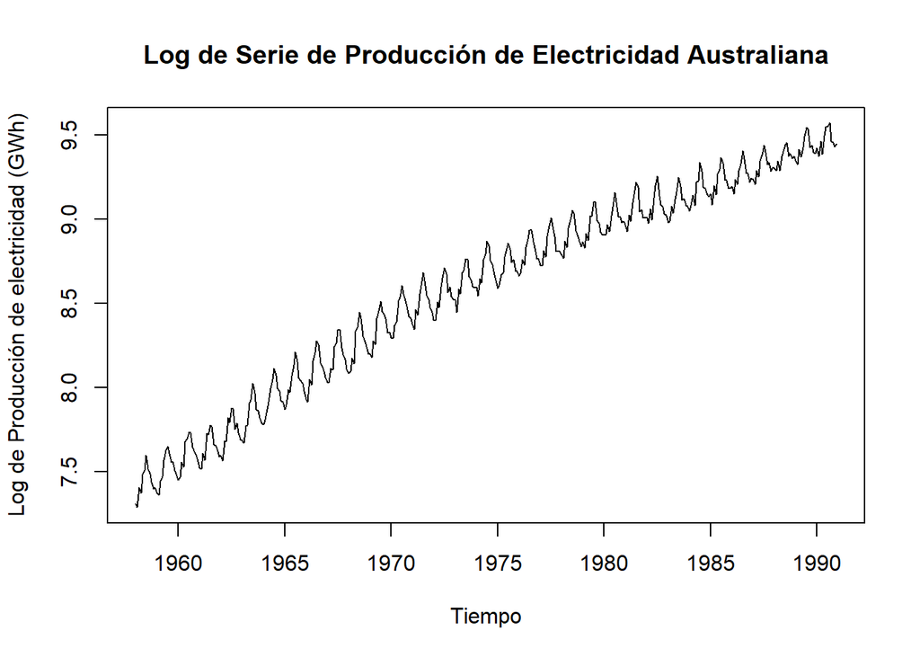

```r
###

plot(log(Elec.ts), xlab = "", ylab = "")
title(main = "Log de Serie de Producción de Electricidad Australiana",
      ylab = "Log de Producción de electricidad (GWh)",
      xlab = "Tiempo")
```

```r
###

Elec.AR <- arima(log(Elec.ts), order = c(1, 1, 0),
                 seas = list(order = c(1, 0, 0), 12))

Elec.MA <- arima(log(Elec.ts), order = c(0, 1, 1),
                 seas = list(order = c(0, 0, 1), 12))


AIC(Elec.AR)
```

```
[1] -1764.741
```

```r
AIC(Elec.MA)
```

```
[1] -1361.586
```

```r
###

# Función para buscar un buen modelo

get.best.arima <- function(x.ts, maxord = c(1, 1, 1, 1, 1, 1)){
  best.aic <- 1e8
  n <- length(x.ts)
  for(p in 0:maxord[1])for(d in 0:maxord[2])for(q in 0:maxord[3])
    for(P in 0:maxord[4])for(D in 0:maxord[5])for(Q in 0:maxord[6])
    {
      fit <- arima(x.ts, order = c(p, d, q),
                   seas = list(order = c(P, D, Q),
                               frequency(x.ts)), method = "CSS")
      fit.aic <- -2*fit$loglik + (log(n) + 1)*length(fit$coef)
      if(fit.aic < best.aic){
        best.aic <- fit.aic
        best.fit <- fit
        best.model <- c(p, d, q, P, D, Q)
      }
    }
  list(best.aic, best.fit, best.model)
}

# Nuevo ajuste a los datos de la serie transformada de producción
# de electricidad

best.arima.elec <- get.best.arima(log(Elec.ts),
                                  maxord = c(2, 2, 2, 2, 2, 2))
best.fit.elec <- best.arima.elec[[2]]  # Modelo
best.arima.elec[[3]] # Tipo de modelo (órdenes)
```

```
[1] 0 1 1 2 0 2
```

```r
best.fit.elec
```

```
Call:
arima(x = x.ts, order = c(p, d, q), seasonal = list(order = c(P, D, Q), frequency(x.ts)),
    method = "CSS")

Coefficients:
          ma1    sar1    sar2     sma1     sma2
      -0.6566  0.7315  0.2557  -0.3324  -0.3051
s.e.   0.0420  0.1270  0.1259   0.1279   0.0958

sigma^2 estimated as 0.0004161:  part log likelihood = 976.97
```

```r
best.arima.elec[[1]] # AIC
```

```
[1] -1919.025
```

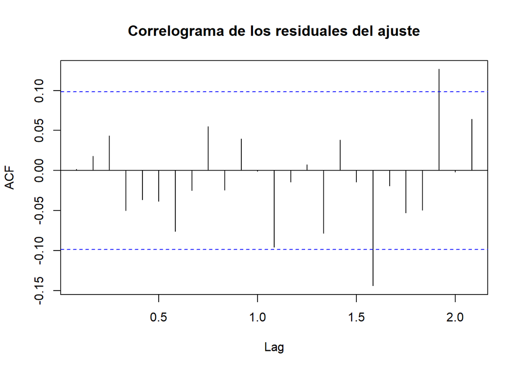

```r
###

# ACF para residuales del ajuste

acf(resid(best.fit.elec), main = "")
title(main = "Correlograma de los residuales del ajuste")
```

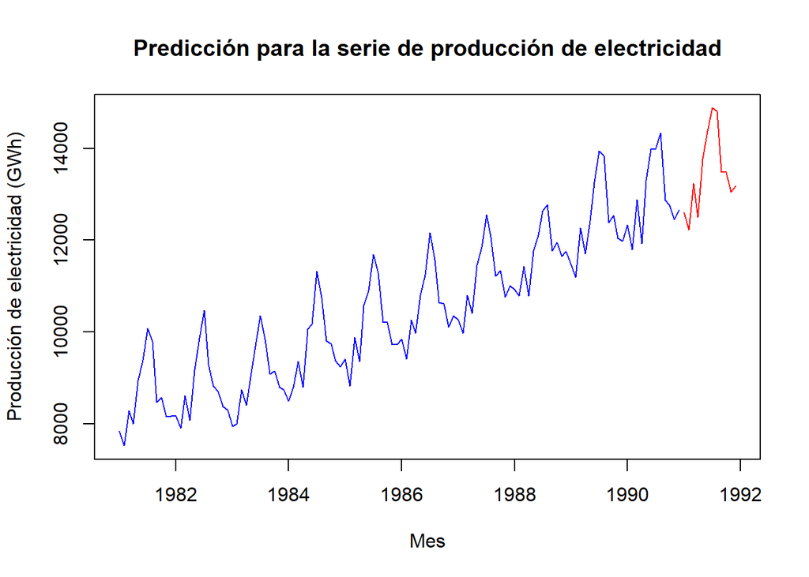

```r
###
# Predicción

pr <- predict(best.fit.elec, 12)$pred
ts.plot(cbind(window(Elec.ts, start = 1981),
              exp(pr)), col = c("blue", "red"), xlab = "")
title(main = "Predicción para la serie de producción de electricidad",
      xlab = "Mes",
      ylab = "Producción de electricidad (GWh)")
```

# RETO 2. SIMULACION DE UN PROCESO ARIMA (1,1,1)

## OBJETIVO

Ajustar un modelo a una serie de tiempo simulada, observar que tan adecuado es el ajuste y realizar algunas predicciones.

## DESARROLLO

1. Realiza la siguiente simulación con las siguientes características: n = 1000 valores de un proceso ARIMA(1, 1, 1) con parámetros ar = 0.6 y ma = 0.2

2.Ajusta un modelo Arima a la serie simulada para estimar los parámetros y observe las estimaciones de los parámetros

3. Obtén el correlograma de los residuales del ajuste
4. Realiza tres predicciones con ayuda del modelo ajustado y la función $predict$

```r
# Reto 2. Proceso ARIMA(1, 1, 1)

# 1. Simula n = 1000 valores de un proceso ARIMA(1, 1, 1) con parámetros
# ar = 0.6 y ma = 0.2

# 2. Ajusta un modelo Arima a la serie simulada para estimar los
# parámetros y observa las estimaciones de los parámetros

# 3. Obtén el correlograma de los residuales del ajuste

# 4. Realiza tres predicciones con ayuda del modelo ajustado y la función
# `predict`

# **Solución**

# A continuación, simulamos datos de un modelo ARIMA(1, 1, 1)

set.seed(9)
x <- arima.sim(model = list(order = c(1, 1, 1),
                            ar = 0.6, ma = 0.2), n = 1000)

# ajustamos un modelo a la serie simulada para recuperar los parámetros
# estimados

fit <- arima(x, order = c(1, 1, 1))

# observamos las estimaciones de los parámetros

coefficients(fit)
```

```
      ar1       ma1
0.5694063 0.2042077
```

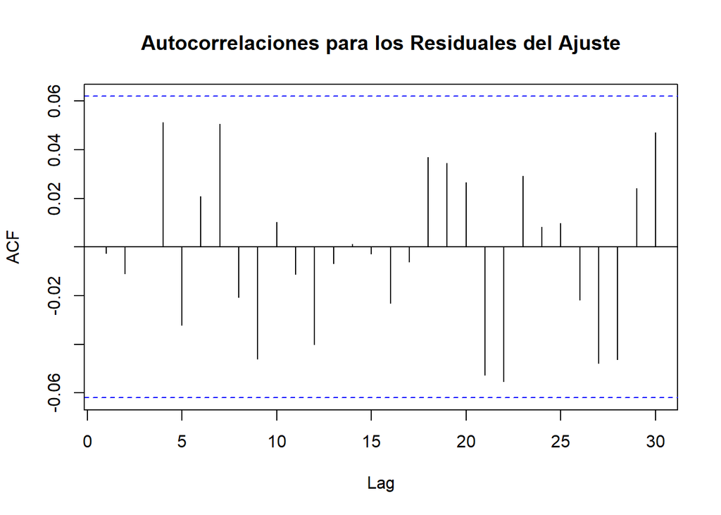

```r
# obtenemos el correlograma de los residuales del ajuste

acf(resid(fit), main = "")
title(main = "Autocorrelaciones para los Residuales del Ajuste")
```

```r
# Llevamos a cabo tres predicciones con el modelo ajustado y la función `predict`

pred <- predict(fit, n.ahead = 3)
pred$pred
```

```
Time Series:
Start = 1002
End = 1004
Frequency = 1
[1] 27.23524 28.00449 28.44251
```

# RETO 3. GRAFICA DE SERIES DE TIEMPO

## OBJETIVO

Utilizar las funciones $ts$ y $ts.plot$ para crear series de tiempo en `R`

## DESARROLLO

Con el conjunto de datos soccer.csv realiza lo siguiente

Crea un data frame para el Barcelona que indique el número de goles anotados en cada fecha que ha jugado.

Obtén un data frame que indique el promedio de goles anotados en cada mes que ha jugado

Crea una serie de tiempo mensual para el número promedio de goles anotados por el Barcelona

Realiza los pasos 1 a 3 para el Real Madrid

Muestra en una misma imagen las gráficas de las series de tiempo anteriores

```r
# RETO 3 SESION 6
# Reto 3. Gráfica de series de tiempo

# Objetivo

# Utilizar las funciones `ts` y `ts.plot` para crear series de tiempo en `R`.

# Requisitos

# Tener instalado R y RStudio
# Haber trabajado con el Prework y el Work

# Desarrollo

# Con el conjunto de datos soccer.csv realiza lo siguiente

# 1. Crea un data frame para el Barcelona que indique el número de goles
# anotados en cada fecha que ha jugado.

# 2. Obtén un data frame que indique el promedio de goles anotados en cada
# mes que ha jugado

# 3. Crea una serie de tiempo mensual para el número promedio de goles
# anotados por el Barcelona

# 4. Realiza los pasos 1 a 3 para el Real Madrid

# 5. Muestra en una misma imagen las gráficas de las series de tiempo
# anteriores

# **Solución**
library(dplyr)
data <- read.csv("soccer.csv")
data <- mutate(data, date = as.Date(date, "%Y-%m-%d"))

# Anotaciones y fechas como local

d1 <- data %>% select(date, home.team, home.score) %>%
  filter(home.team == "Barcelona") %>%
  rename(team = home.team, score = home.score)

# Anotaciones y fechas como visitante

d2 <- data %>% select(date, away.team, away.score) %>%
  filter(away.team == "Barcelona") %>%
  rename(team = away.team, score = away.score)

# data frame de anotaciones y fechas

d <- rbind(d1, d2)

# data frame de promedio de anotaciones en cada mes

d <- mutate(d, Ym = format(date, "%Y-%m"))
barca <- d %>% group_by(Ym) %>% summarise(goles = mean(score))

# Creación de la serie de tiempo

# A partir de agosto 2017

(barca <- ts(barca$goles, start = c(1, 1), end = c(3, 5), # Hasta diciembre de 2019
             frequency = 10))
```

```
Time Series:
Start = c(1, 1)
End = c(3, 5)
Frequency = 10
 [1] 2.000000 4.000000 2.000000 2.000000 2.750000 3.500000 2.250000 1.600000
 [9] 2.750000 3.000000 2.000000 2.800000 3.333333 2.333333 3.250000 2.500000
[17] 1.750000 2.500000 1.833333 1.333333 2.333333 2.250000 4.000000 2.333333
[25] 2.400000
```

```r
######

# Anotaciones y fechas como local

d1 <- data %>% select(date, home.team, home.score) %>%
  filter(home.team == "Real Madrid") %>%
  rename(team = home.team, score = home.score)

# Anotaciones y fechas como visitante

d2 <- data %>% select(date, away.team, away.score) %>%
  filter(away.team == "Real Madrid") %>%
  rename(team = away.team, score = away.score)

# data frame de anotaciones y fechas

d <- rbind(d1, d2)

# data frame de promedio de anotaciones en cada mes

d <- mutate(d, Ym = format(date, "%Y-%m"))
realM <- d %>% group_by(Ym) %>% summarise(goles = mean(score))

# Creación de la serie de tiempo

(realM <- ts(realM$goles, start = c(1, 1), # A partir de agosto 2017
             frequency = 10, end = c(3, 5))) # Hasta diciembre de 2019
```

```
Time Series:
Start = c(1, 1)
End = c(3, 5)
Frequency = 10
 [1] 2.5000000 1.5000000 2.0000000 2.0000000 1.6666667 3.2500000 3.1666667
 [8] 3.5000000 1.5000000 3.0000000 3.0000000 1.2000000 0.6666667 2.0000000
[15] 1.3333333 2.0000000 2.2500000 2.2500000 1.1666667 1.3333333 2.0000000
[22] 1.6000000 3.0000000 2.2500000 0.7500000
```

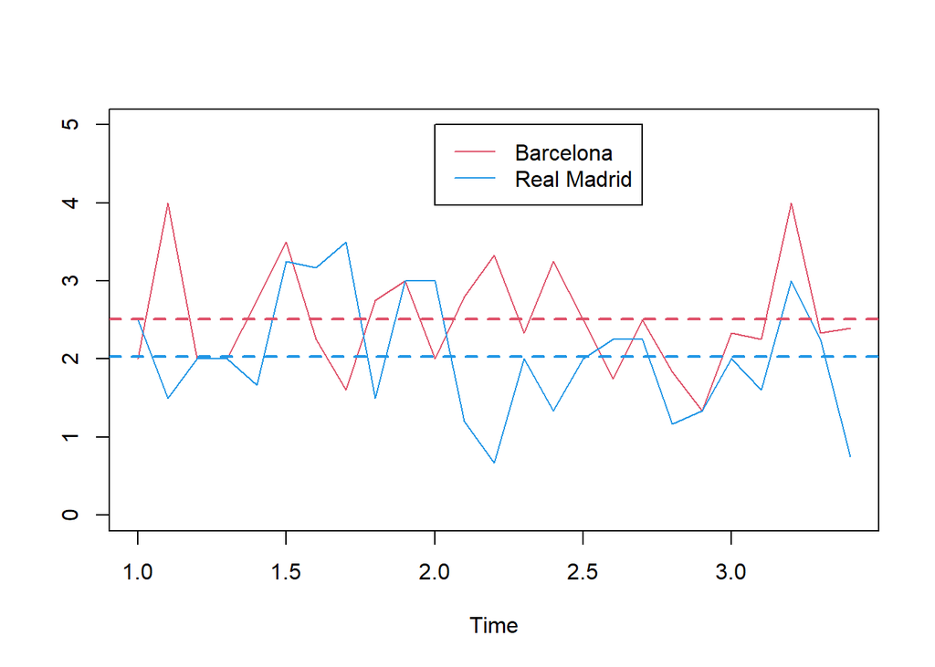

```r
######

# Gráficas de series de tiempo

ts.plot(cbind(barca, realM), col = c(2, 4), ylim = c(0, 5))
abline(h = mean(barca), lwd = 2, col = 2, lty = 2)
abline(h = mean(realM), lwd = 2, col = 4, lty = 2)
legend(x = 2, y = 5,
       legend = c("Barcelona", "Real Madrid"),
       col = c(2, 4), lty = c(1, 1))
```